# Exploratory Data Analysis Project

### Perusing the Data Tables

```r
head(GDP)
```

|  | LOCATION | INDICATOR | SUBJECT | MEASURE | FREQUENCY | TIME | Value | Flag.Codes |
| --- | --- | --- | --- | --- | --- | --- | --- | --- |
| 1 | KOR | QGDP | TOT | PC_CHGPP | Q | 2000-Q1 | 1.895052 |  |
| 2 | KOR | QGDP | TOT | PC_CHGPP | Q | 2000-Q2 | 1.332510 |  |
| 3 | KOR | QGDP | TOT | PC_CHGPP | Q | 2000-Q3 | 2.754591 |  |
| 4 | KOR | QGDP | TOT | PC_CHGPP | Q | 2000-Q4 | -0.324458 |  |
| 5 | KOR | QGDP | TOT | PC_CHGPP | Q | 2001-Q1 | 1.225555 |  |
| 6 | KOR | QGDP | TOT | PC_CHGPP | Q | 2001-Q2 | 1.298881 |  |

```r
summary(GDP)
```

```
    LOCATION    INDICATOR   SUBJECT        MEASURE     FREQUENCY      TIME
 ARG    :  82   QGDP:4207   TOT:4207   PC_CHGPP:4207   Q:4207    2015-Q2:  53
 AUS    :  82                                                    2015-Q3:  53
 AUT    :  82                                                    2015-Q4:  53
 BEL    :  82                                                    2016-Q1:  53
 BGR    :  82                                                    2016-Q2:  53
 BRA    :  82                                                    2016-Q3:  53
 (Other):3715                                                    (Other):3889
     Value          Flag.Codes
 Min.   :-25.2481    :4015
 1st Qu.:  0.1505   B:   2
 Median :  0.6273   E: 118
 Mean   :  0.4817   P:  72
 3rd Qu.:  1.1564
 Max.   : 23.3915
```

```r
head(UNEMPL)
```

|  | LOCATION | INDICATOR | SUBJECT | MEASURE | FREQUENCY | TIME | Value | Flag.Codes |
| --- | --- | --- | --- | --- | --- | --- | --- | --- |
| 1 | AUS | HUR | TOT | PC_LF | Q | 2000-Q1 | 6.650708 |  |
| 2 | AUS | HUR | TOT | PC_LF | Q | 2000-Q2 | 6.302083 |  |
| 3 | AUS | HUR | TOT | PC_LF | Q | 2000-Q3 | 5.989491 |  |
| 4 | AUS | HUR | TOT | PC_LF | Q | 2000-Q4 | 6.171560 |  |
| 5 | AUS | HUR | TOT | PC_LF | Q | 2001-Q1 | 6.366835 |  |
| 6 | AUS | HUR | TOT | PC_LF | Q | 2001-Q2 | 6.869637 |  |

```r
summary(UNEMPL)
```

```
    LOCATION    INDICATOR  SUBJECT     MEASURE     FREQUENCY      TIME
 AUS    :  82   HUR:3348   TOT:3348   PC_LF:3348   Q:3348    2007-Q2:  42
 AUT    :  82                                                2008-Q2:  42
 BEL    :  82                                                2009-Q2:  42
 CAN    :  82                                                2010-Q1:  42
 CHL    :  82                                                2010-Q2:  42
 CZE    :  82                                                2010-Q3:  42
 (Other):2856                                                (Other):3096
     Value        Flag.Codes
 Min.   : 1.867    :3183
 1st Qu.: 5.000   B:   5
 Median : 6.933   E: 160
 Mean   : 7.668
 3rd Qu.: 9.200
 Max.   :27.833
```

```r
head(mlp)
```

|  | RegionID | SizeRank | RegionName | RegionType | StateName | X2017.10.14 | X2017.10.21 | X2017.10.28 | X2017.11.04 | X2017.11.11 | X2017.11.18 | X2017.11.25 | X2017.12.02 | X2017.12.09 | X2017.12.16 | X2017.12.23 | X2017.12.30 | X2018.01.06 | X2018.01.13 | X2018.01.20 | X2018.01.27 | X2018.02.03 | X2018.02.10 | X2018.02.17 | X2018.02.24 | X2018.03.03 | X2018.03.10 | X2018.03.17 | X2018.03.24 | … |
| --- | --- | --- | --- | --- | --- | --- | --- | --- | --- | --- | --- | --- | --- | --- | --- | --- | --- | --- | --- | --- | --- | --- | --- | --- | --- | --- | --- | --- | --- | --- |
| 1 | 102001 | 0 | United States | Country |  | 275000 | 275000 | 277800 | 275000 | 275000 | 275000 | 274900 | 274650 | 272500 | 270000 | 269900 | 269900 | 269900 | 269900 | 270000 | 274138 | 274900 | 275000 | 279000 | 279900 | 282500 | 285000 | 289000 | 289900 | … |
| 2 | 394913 | 1 | New York, NY | Msa | NY | 528873 | 528873 | 532903 | 528873 | 528873 | 528873 | 528873 | 528873 | 528773 | 523836 | 523836 | 522829 | 522829 | 523836 | 528873 | 528873 | 532903 | 538947 | 549021 | 552043 | 553050 | 553957 | 553957 | 553957 | … |
| 3 | 753899 | 2 | Los Angeles-Long Beach-Anaheim, CA | Msa | CA | 808785 | 814936 | 808785 | 811859 | 808785 | 809809 | 814936 | 817107 | 816986 | 819036 | 819036 | 819036 | 814936 | 815551 | 819036 | 819036 | 819958 | 819036 | 819958 | 835437 | 849788 | 860039 | 856962 | 860039 | … |
| 4 | 394463 | 3 | Chicago, IL | Msa | IL | 315000 | 315000 | 314900 | 310000 | 309900 | 305000 | 300000 | 299900 | 299900 | 299000 | 297900 | 295000 | 295000 | 295000 | 299000 | 299900 | 303722 | 310000 | 319900 | 324900 | 329000 | 333000 | 338995 | 339900 | … |
| 5 | 394514 | 4 | Dallas-Fort Worth, TX | Msa | TX | 344000 | 344000 | 343000 | 340000 | 340000 | 339900 | 339900 | 340000 | 339990 | 342345 | 340000 | 341345 | 344700 | 341173 | 344700 | 347500 | 349000 | 349900 | 350000 | 355000 | 358858 | 359900 | 359900 | 359900 | … |
| 6 | 394974 | 5 | Philadelphia, PA | Msa | PA | 259900 | 259900 | 260000 | 259900 | 259900 | 258000 | 254900 | 250000 | 250000 | 250000 | 249900 | 245900 | 245000 | 247000 | 245000 | 248800 | 249000 | 249900 | 250000 | 250000 | 256990 | 259900 | 259900 | 264900 | … |

```r
head(inv)
```

|  | RegionID | SizeRank | RegionName | RegionType | StateName | X2017.10.14 | X2017.10.21 | X2017.10.28 | X2017.11.04 | X2017.11.11 | X2017.11.18 | X2017.11.25 | X2017.12.02 | X2017.12.09 | X2017.12.16 | X2017.12.23 | X2017.12.30 | X2018.01.06 | X2018.01.13 | X2018.01.20 | X2018.01.27 | X2018.02.03 | X2018.02.10 | X2018.02.17 | X2018.02.24 | X2018.03.03 | X2018.03.10 | X2018.03.17 | X2018.03.24 | … |
| --- | --- | --- | --- | --- | --- | --- | --- | --- | --- | --- | --- | --- | --- | --- | --- | --- | --- | --- | --- | --- | --- | --- | --- | --- | --- | --- | --- | --- | --- | --- |
| 1 | 102001 | 0 | United States | Country |  | 1325462 | 1320444 | 1304379 | 1299029 | 1282786 | 1268501 | 1231202 | 1223943 | 1191988 | 1156733 | 1144772 | 1090052 | 1090054 | 1084404 | 1084918 | 1091567 | 1102962 | 1102843 | 1111952 | 1115262 | 1139209 | 1124862 | 1184780 | 1176533 | … |
| 2 | 394913 | 1 | New York, NY | Msa | NY | 66856 | 66733 | 65730 | 65248 | 63739 | 62956 | 60799 | 60583 | 58559 | 56659 | 55289 | 52507 | 52293 | 51699 | 52278 | 53117 | 54263 | 57470 | 57093 | 57383 | 60580 | 59904 | 62479 | 62382 | … |
| 3 | 753899 | 2 | Los Angeles-Long Beach-Anaheim, CA | Msa | CA | 18046 | 17892 | 17349 | 17065 | 16675 | 16439 | 15463 | 15338 | 14699 | 13798 | 13561 | 11859 | 12149 | 12820 | 13355 | 13747 | 14120 | 14709 | 14819 | 15080 | 15462 | 15049 | 16655 | 16222 | … |
| 4 | 394463 | 3 | Chicago, IL | Msa | IL | 38296 | 37890 | 37336 | 36710 | 35648 | 34715 | 33135 | 32584 | 31490 | 30099 | 29347 | 27423 | 26988 | 27267 | 27493 | 27667 | 27922 | 28310 | 28721 | 29056 | 30628 | 30692 | 32944 | 32513 | … |
| 5 | 394514 | 4 | Dallas-Fort Worth, TX | Msa | TX | 22122 | 21828 | 21776 | 21707 | 20983 | 20852 | 20086 | 19773 | 19003 | 18101 | 17998 | 16365 | 16112 | 16406 | 16757 | 17023 | 17366 | 17235 | 17524 | 17368 | 17576 | 17168 | 19110 | 19025 | … |
| 6 | 394974 | 5 | Philadelphia, PA | Msa | PA | 24217 | 24034 | 24435 | 24631 | 25490 | 24093 | 23666 | 22692 | 21831 | 21221 | 20692 | 19599 | 19275 | 19006 | 19250 | 19422 | 19642 | 19527 | 19986 | 20275 | 20815 | 20156 | 21390 | 21205 | … |

### Cleaning and Augmenting Data Sets

Here, I use the COUNTRYCODES data set to add a country name variable to each case according to its country code. Additionally, I convert some variables from factor type to character string type.

```r
GDP_refined <- merge(GDP, COUNTRYCODES, by.x = "LOCATION", by.y = "CODE") %>%
  mutate(
    LOCATION = as.character(LOCATION),
    INDICATOR = as.character(INDICATOR),
    Country = as.character(Country)
  )

UNEMPL_refined <- merge(UNEMPL, COUNTRYCODES, by.x = "LOCATION", by.y = "CODE") %>%
  mutate(
    LOCATION = as.character(LOCATION),
    INDICATOR = as.character(INDICATOR),
    Country = as.character(Country)
  )

head(GDP_refined)
```

|  | LOCATION | INDICATOR | SUBJECT | MEASURE | FREQUENCY | TIME | Value | Flag.Codes | Country | X | X.1 |
| --- | --- | --- | --- | --- | --- | --- | --- | --- | --- | --- | --- |
| 1 | ARG | QGDP | TOT | PC_CHGPP | Q | 2000-Q3 | -0.2551851 |  | Argentina | NA |  |
| 2 | ARG | QGDP | TOT | PC_CHGPP | Q | 2000-Q4 | 0.3068581 |  | Argentina | NA |  |
| 3 | ARG | QGDP | TOT | PC_CHGPP | Q | 2001-Q3 | -4.6458789 |  | Argentina | NA |  |
| 4 | ARG | QGDP | TOT | PC_CHGPP | Q | 2014-Q1 | -1.4862948 |  | Argentina | NA |  |
| 5 | ARG | QGDP | TOT | PC_CHGPP | Q | 2013-Q4 | -0.9738341 |  | Argentina | NA |  |
| 6 | ARG | QGDP | TOT | PC_CHGPP | Q | 2000-Q2 | -1.6088925 |  | Argentina | NA |  |

```r
head(UNEMPL_refined)
```

|  | LOCATION | INDICATOR | SUBJECT | MEASURE | FREQUENCY | TIME | Value | Flag.Codes | Country | X | X.1 |
| --- | --- | --- | --- | --- | --- | --- | --- | --- | --- | --- | --- |
| 1 | AUS | HUR | TOT | PC_LF | Q | 2011-Q2 | 4.963495 |  | Australia | NA |  |
| 2 | AUS | HUR | TOT | PC_LF | Q | 2010-Q3 | 5.120329 |  | Australia | NA |  |
| 3 | AUS | HUR | TOT | PC_LF | Q | 2010-Q4 | 5.090347 |  | Australia | NA |  |
| 4 | AUS | HUR | TOT | PC_LF | Q | 2011-Q3 | 5.188880 |  | Australia | NA |  |
| 5 | AUS | HUR | TOT | PC_LF | Q | 2011-Q4 | 5.205238 |  | Australia | NA |  |
| 6 | AUS | HUR | TOT | PC_LF | Q | 2012-Q1 | 5.146834 |  | Australia | NA |  |

### Determining Average Economic Health

#### United States vs. Other G7 Countries

We can see from the box plot below that the United States has had more consistent GDP growth over the last two decades than most of the other G7 countries. I can make this assertion because the upper 75% of quarterly GDP changes have been positive in the US. Excluding a few outlier quarters, the vast majority of US quarters have had positive GDP growth. Furthermore, the United States has had lower unemployment rates than most other G7 countries over the past two decades. Therefore, it is reasonable to say that the United States economy is likely the strongest in the world in regular times. It also follows that the highly stable economy of the United States should have been able to weather the pandemic much more easily than other countries.

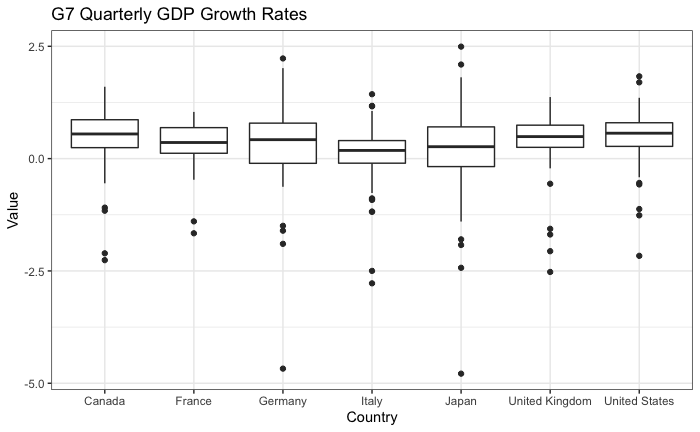

```r
avg_gdp_g7_boxplot <- GDP_refined %>%
  filter(Country %in% c("United States", "France", "Germany", "United Kingdom", "Canada", "Italy", "Japan")) %>%
  filter(Value < 5 & Value > -5) %>%
  ggplot(aes(x = Country, y = Value)) +
  geom_boxplot() +
  theme_bw() +
  ggtitle("G7 Quarterly GDP Growth Rates")

avg_gdp_g7_boxplot
```

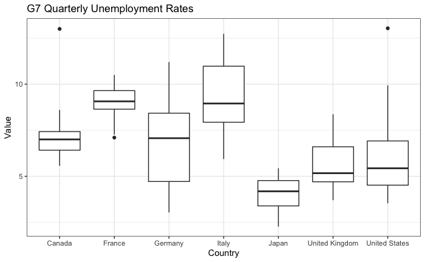

```r
avg_unempl_g7_boxplot <- UNEMPL_refined %>%
  filter(Country %in% c("United States", "France", "Germany", "United Kingdom", "Canada", "Italy", "Japan")) %>%
  ggplot(aes(x = Country, y = Value)) +
  geom_boxplot() +
  theme_bw() +
  ggtitle("G7 Quarterly Unemployment Rates")

avg_unempl_g7_boxplot
```

#### Important Caveat

It is important to note that I only compared the United States to other superpower economies because it does not make sense to compare the US economy to developing ones. Those countries have high growth rates because even small increases in nominal GDP, relative to those of the superpower economies, result in large percentage changes. However, their high growth rates do not imply they were as economically stable as the US prior to the coronavirus pandemic. We can see this phenomenon below.

[figure not shown]

```r
avg_gdp_developing_plot <- GDP_refined %>%
  filter(Country %in% c("United States", "Turkey", "Israel", "Brazil", "Argentina", "India")) %>%
  filter(Value < 5 & Value > -5) %>%
  ggplot(aes(x = Country, y = Value)) +
  geom_boxplot() +
  theme_bw() +
  ggtitle("G7 Quarterly GDP Growth Rates")

avg_gdp_developing_plot
```

### 2020-Q2 Economic Health

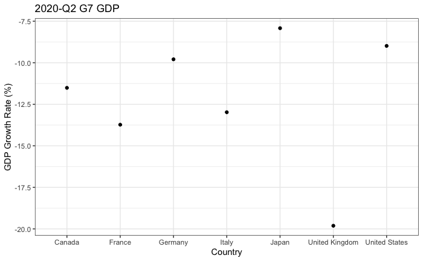

```r
# Rendering dot plots of GDP growth rate in 2020-Q2 for G7 countries
q2_2020_gdpchange.g7plot <- GDP_refined %>%
  filter(Country %in% c("United States", "France", "Germany", "United Kingdom", "Canada", "Italy", "Japan")) %>%
  filter(TIME == "2020-Q2") %>%
  ggplot(aes(x = Country, y = Value)) +
  geom_point() +
  theme_bw() +
  ggtitle("2020-Q2 G7 GDP") +
  ylab("GDP Growth Rate (%)")

q2_2020_gdpchange.g7plot
```

```r
# Calculating average GDP growth rate in 2020-Q2 for all countries excluding the US
q2_2020_gdpchange.excl_us <- GDP_refined %>%
  filter(!(LOCATION %in% c("United States"))) %>%
  filter(TIME == "2020-Q2") %>%
  summarise(avg_change = mean(Value))

q2_2020_gdpchange.excl_us
```

| avg_change |
| --- |
| -10.62356 |

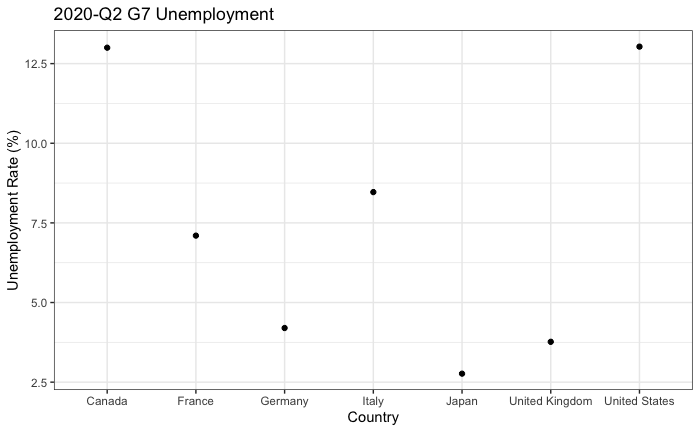

```r
# Rendering dot plot for unemployment rate in 2020-Q2 for G7 countries
q2_2020_unempl.g7plot <- UNEMPL_refined %>%
  filter(Country %in% c("United States", "France", "Germany", "United Kingdom", "Canada", "Italy", "Japan")) %>%
  filter(TIME == "2020-Q2") %>%
  ggplot(aes(x = Country, y = Value)) +
  geom_point() +
  theme_bw() +
  ggtitle("2020-Q2 G7 Unemployment") +
  ylab("Unemployment Rate (%)")

q2_2020_unempl.g7plot
```

```r
# Calculating average unemployment rate in 2020-Q2 for all countries excluding the US
q2_2020_unempl.excl_us <- UNEMPL_refined %>%
  filter(!(LOCATION %in% c("United States"))) %>%
  filter(TIME == "2020-Q2") %>%
  summarise(average_rate = mean(Value))

q2_2020_unempl.excl_us
```

| average_rate |
| --- |
| 7.519634 |

### Economic Impact in Context

The visualizations below can give the reader insight into how the four largest economies in the world performed in the context of their previous performance. We can see from the first graph, titled “GDP in Context”, that the GDP of the United States shrunk less drastically than that of every other country except Japan. From the graph titled “Unemployment in Context”, we can see that the US unemployment rate far exceeded that of the other mega-economies.

```r
getGDPTimeSeries <- function () {

  ret <- GDP_refined %>%
    filter(Country %in% c("United States", "Germany", "United Kingdom", "Japan")) %>%
    mutate(TIME = as.Date(as.yearqtr(TIME, "%Y-Q%q")))

  return(ret)

}

getUnemplTimeSeries <- function () {

  ret <- UNEMPL_refined %>%
    filter(Country %in% c("United States", "Germany", "United Kingdom", "Japan")) %>%
    mutate(TIME = as.Date(as.yearqtr(TIME, "%Y-Q%q")))

  return(ret)

}
```

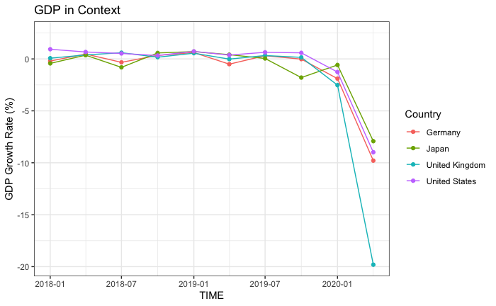

```r
# Renders line, and overlaid dot plot, of the time series
# of GDP growth rates for the world's four largest economies
getGDPTimeSeries() %>%
  ggplot(aes(x = TIME, y = Value, color = Country)) +
  geom_line() +
  geom_point() +
  xlim(as.Date(as.yearqtr("2018-Q1", "%Y-Q%q")), as.Date(as.yearqtr("2020-Q2", "%Y-Q%q"))) +
  ggtitle("GDP in Context") +
  ylab("GDP Growth Rate (%)") +
  theme_bw()
```

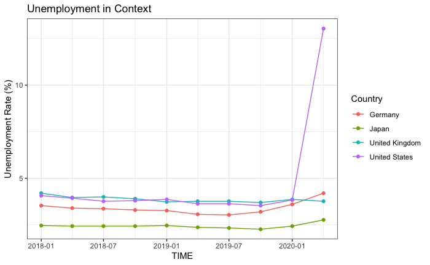

```r
# Renders line, and overlaid dot plot, of the time series
# of unemployment rates for the world's four largest economies
getUnemplTimeSeries() %>%
  ggplot(aes(x = TIME, y = Value, color = Country)) +
  geom_line() +
  geom_point() +
  xlim(as.Date(as.yearqtr("2018-Q1", "%Y-Q%q")), as.Date(as.yearqtr("2020-Q2", "%Y-Q%q"))) +
  ggtitle("Unemployment in Context") +
  ylab("Unemployment Rate (%)") +
  theme_bw()
```

### Judging Impact on Ordinary People

After noticing the unusually high unemployment rate in the US, I hypothesized that the lack of income among millions of ordinary Americans would exhibit itself in the prices and for-sale quantities of widely-held assets. It is common knowledge that ordinary people are heavily invested in homes. Therefore, to judge the impact of the coronavirus pandemic on ordinary people, I chose to analyze home prices and quantities of for-sale homes. Before looking at the data, I reasoned that home prices should have decreased and for-sale home quantity should have increased if the coronavirus pandemic had severely negatively impacted ordinary Americans. This hypothesis resulted from my belief that struggling Americans would have been forced to sell their homes if they lost the ability to pay their mortgages.

```r
# Getting the column names that identify dates of measurements
cols <- colnames(mlp)[6:length(colnames(mlp))]

# Transforming wide median price dataframe into narrow format for
# Easier manipulation and changing string Date to lubridate object
mlp.refined <- mlp %>%
  select(RegionName, cols) %>%
  gather(key = when, value = MedianPrice, cols) %>%
  mutate(when = gsub(pattern = "X", replacement = "", when)) %>%
  mutate(Date = lubridate::ymd(when), MedianPrice = MedianPrice / 1000) %>%
  arrange(Date) %>%
  select(RegionName, MedianPrice, Date)

# Getting most recent median housing prices for all cities
# And arranging them from most expensive to least expensive
mlp.final <- mlp.refined %>%
  filter(Date == "2020-10-31") %>%
  arrange(desc(MedianPrice))

# Getting the top 10 cheapest and most expensive cities
cheap_cities <- mlp.final$RegionName[87:97]
expensive_cities <- mlp.final$RegionName[1:10]
```

```r
showMP <- function (which_cities, title) {

  mlp.refined %>%
    filter(RegionName %in% which_cities, Date > lubridate::ymd("2019-06-01")) %>%
    ggplot(aes(x = Date, y = MedianPrice, color = RegionName)) +
    geom_line() +
    theme_bw() +
    ylab("Median Price (K$)") +
    ggtitle(title)

}
```

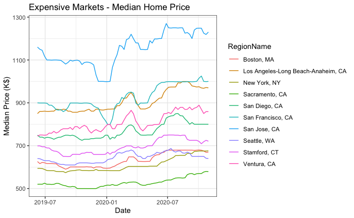

```r
showMP(expensive_cities, "Expensive Markets - Median Home Price")
```

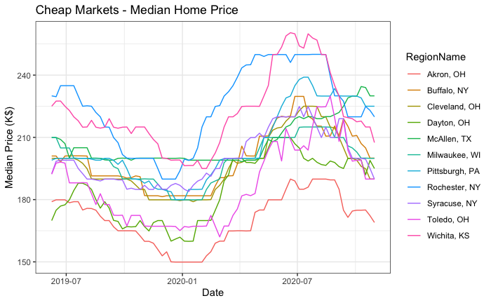

```r
showMP(cheap_cities, "Cheap Markets - Median Home Price")
```

```r
inv.refined <- inv %>%
  select(RegionName, cols) %>%
  gather(key = when, value = Quantity, cols) %>%
  mutate(when = gsub(pattern = "X", replacement = "", when)) %>%
  mutate(Date = lubridate::ymd(when)) %>%
  arrange(Date) %>%
  select(RegionName, Quantity, Date)
```

```r
showQuantity <- function (which_cities, title) {

  inv.refined %>%
    filter(RegionName %in% which_cities, Date > lubridate::ymd("2019-06-01")) %>%
    ggplot(aes(x = Date, y = Quantity, color = RegionName)) +
    geom_line() +
    theme_bw() +
    ylab("Quantity") +
    ggtitle(title)

}
```

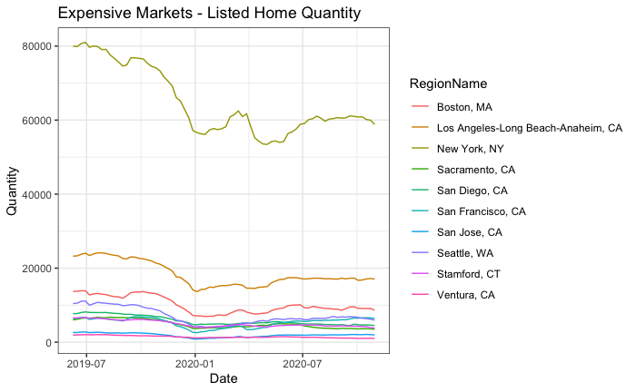

```r
showQuantity(expensive_cities, "Expensive Markets - Listed Home Quantity")
```

```r
# Display inventory time series line chart for most cheap cities
showQuantity(cheap_cities, "Cheap Markets - Listed Home Quantity")
```

[output not shown]

### Embedding Files for Submission Purposes

```r
xfun::embed_file("GDP.csv")
```

Download GDP.csv

```r
xfun::embed_file("UNEMPLOYMENT.csv")
```

Download UNEMPLOYMENT.csv

```r
xfun::embed_file("COUNTRYCODES.csv")
```

Download COUNTRYCODES.csv

```r
xfun::embed_file("MedianListPrice.csv")
```

Download MedianListPrice.csv

```r
xfun::embed_file("Inventory.csv")
```

Download Inventory.csv